# 03 | A map made of numbers

**35 minutes · GeoTIFFs, grid cells and asset sampling**

**By the end:** read raster metadata; explain resolution and nodata; extract a cell value at an asset; distinguish an image from a climate measurement.

**Case question:** What does a gridded heat indicator say at each asset location? Our heat grid is **synthetic** and stores the number of days in 2024 with daily maximum air temperature ≥35°C. The threshold is a teaching choice, not an engineering standard.

```python
from pathlib import Path
import numpy as np
import pandas as pd
import matplotlib.pyplot as plt
from IPython.display import display

# Works when Jupyter starts in the project root or a subfolder.
ROOT = next((p for p in [Path.cwd(), *Path.cwd().parents]
             if (p / 'data/assets.csv').exists()), None)
if ROOT is None:
    raise FileNotFoundError('Keep the notebooks and data folders together; open this project in Jupyter.')
DATA = ROOT / 'data'
OUT = ROOT / 'outputs'
OUT.mkdir(exist_ok=True)
plt.rcParams.update({'figure.figsize': (9, 5), 'font.size': 11,
                     'axes.spines.top': False, 'axes.spines.right': False,
                     'axes.titleweight': 'bold', 'figure.dpi': 110})
print('Ready. Core lessons use bundled local data; no API key needed.')
```

```
Ready. Core lessons use bundled local data; no API key needed.
```

```python
import rasterio
from rasterio.plot import plotting_extent
import geopandas as gpd
points = gpd.read_file(DATA / 'assets.geojson')
with rasterio.open(DATA / 'synthetic_hot_days_2024.tif') as src:
    heat = src.read(1, masked=True)
    extent = plotting_extent(src)
    display(pd.Series({'CRS':str(src.crs),'rows':src.height,'columns':src.width,
                       'bands':src.count,'cell size (degrees)':src.res,'nodata marker':src.nodata}))
    print('Metadata:', src.tags())
    print('Top-left 3 by 3 cells ( -- means missing):')
    print(heat[:3,:3])
```

```
CRS                       EPSG:4326
rows                              6
columns                           6
bands                             1
cell size (degrees)    (0.05, 0.05)
nodata marker               -9999.0
dtype: object
```

```
Metadata: {'source': 'SYNTHETIC teaching data', 'threshold_c': '35', 'units': 'days', 'year': '2024', 'AREA_OR_POINT': 'Area'}
Top-left 3 by 3 cells ( -- means missing):
[[-- 53.0 54.0]
 [62.0 67.0 69.0]
 [79.0 81.0 85.0]]
```

## 1. Read the grid before reading the colors

The dataset is just 6 × 6 cells. Its 0.05-degree spacing is several kilometres here, not rooftop resolution. The top-left cell is deliberately missing. A **nodata** marker represents “no valid value,” not zero days.

The same grid could be colored many ways. The legend's variable, units, period and threshold matter more than the palette. [Rasterio's mask guide](https://rasterio.readthedocs.io/en/stable/topics/masks.html) explains how missing cells are represented.

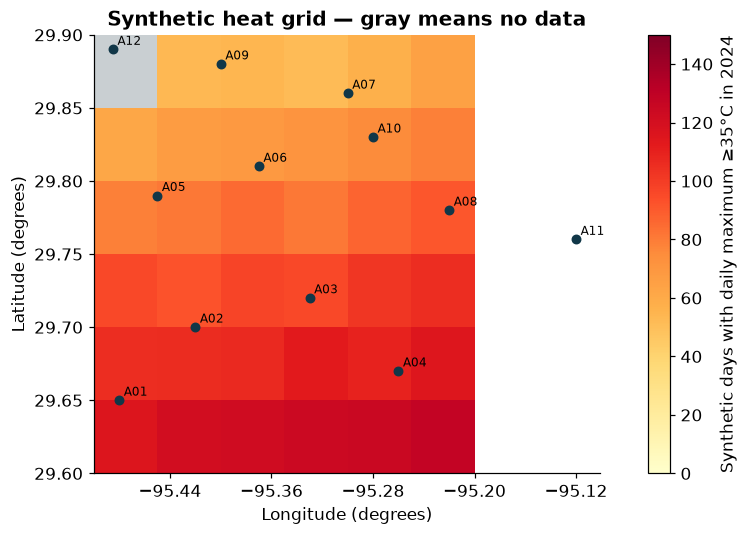

```python
fig, ax = plt.subplots()
cmap = plt.colormaps['YlOrRd'].copy()
cmap.set_bad('#c9cfd2')
im = ax.imshow(heat, extent=extent, origin='upper', cmap=cmap, vmin=0, vmax=150)
points.plot(ax=ax,color='#113748',markersize=30)
for row in points.itertuples():
    ax.annotate(row.asset_id,(row.geometry.x,row.geometry.y),xytext=(3,3),textcoords='offset points',fontsize=8)
fig.colorbar(im,ax=ax,label='Synthetic days with daily maximum ≥35°C in 2024')
ax.set(xlabel='Longitude (degrees)',ylabel='Latitude (degrees)',title='Synthetic heat grid — gray means no data')
from matplotlib.ticker import MaxNLocator
ax.xaxis.set_major_locator(MaxNLocator(5))
plt.tight_layout()
plt.show()
```

## 2. Put the grid value back into a table

Sampling chooses the cell containing a coordinate; it does not measure conditions inside the building. We explicitly check the extent and nodata. A11 is outside the grid; A12 is inside a missing cell. Both remain **unknown**.

```python
records = []
with rasterio.open(DATA / 'synthetic_hot_days_2024.tif') as src:
    projected = points.to_crs(src.crs)
    for row in projected.itertuples():
        x, y = row.geometry.x, row.geometry.y
        inside = src.bounds.left <= x < src.bounds.right and src.bounds.bottom < y <= src.bounds.top
        value = np.nan
        status = 'outside grid'
        if inside:
            sample = next(src.sample([(x,y)],masked=True))[0]
            if np.ma.is_masked(sample) or not np.isfinite(sample):
                status = 'missing cell'
            else:
                value, status = float(sample), 'available'
        records.append({'asset_id':row.asset_id,'hot_days':value,'coverage':status})
sampled = pd.DataFrame(records)
display(sampled)
assert sampled.hot_days.isna().sum() == 2
```

|  | asset_id | hot_days | coverage |
| --- | --- | --- | --- |
| 0 | A01 | 116.0 | available |
| 1 | A02 | 92.0 | available |
| 2 | A03 | 96.0 | available |
| 3 | A04 | 109.0 | available |
| 4 | A05 | 79.0 | available |
| 5 | A06 | 69.0 | available |
| 6 | A07 | 57.0 | available |
| 7 | A08 | 91.0 | available |
| 8 | A09 | 53.0 | available |
| 9 | A10 | 75.0 | available |
| 10 | A11 | NaN | outside grid |
| 11 | A12 | NaN | missing cell |

## 3. A real satellite file: inspect, do not over-interpret

The separate `real_satellite_example.tif` was copied from your local Planet teaching repository. We inspect its metadata and first band. The acquisition date, calibration and interpretation have not been independently verified here. A sensor band's pixel values are not automatically air temperature, vegetation health or asset value.

```
Real example: 1992 columns x 2423 rows; 4 bands
CRS: EPSG:32611 | Pixel size in CRS units: (3.0, 3.0)
Band descriptions: (None, None, None, None)
```

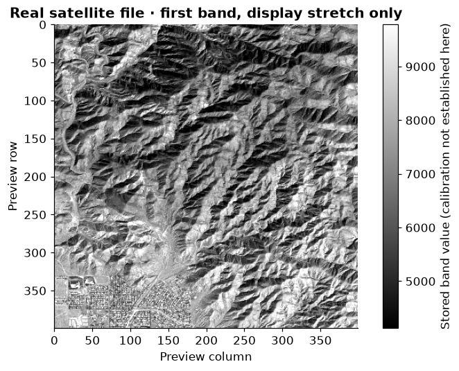

```python
real_path = DATA / 'real_satellite_example.tif'
if real_path.exists():
    with rasterio.open(real_path) as src:
        print('Real example:', src.width, 'columns x', src.height, 'rows;', src.count, 'bands')
        print('CRS:', src.crs, '| Pixel size in CRS units:', src.res)
        print('Band descriptions:', src.descriptions)
        band = src.read(1,out_shape=(min(400,src.height),min(400,src.width)),masked=True)
    valid = band.compressed()
    low, high = np.percentile(valid,[2,98])
    fig, ax = plt.subplots(figsize=(7,5))
    im = ax.imshow(band,cmap='gray',vmin=low,vmax=high)
    ax.set(title='Real satellite file · first band, display stretch only',xlabel='Preview column',ylabel='Preview row')
    fig.colorbar(im,ax=ax,label='Stored band value (calibration not established here)')
    plt.tight_layout()
    plt.show()
else:
    print('Optional real image not bundled. The synthetic raster lesson remains complete.')
```

## Try it · 5 minutes

1. What could differ between two buildings in the same heat-grid cell?
2. Why would replacing missing values with zero be misleading?
3. Compare the real image's dimensions with the 6 × 6 heat grid. Does more detail always mean more useful evidence for your question?

**Coding extension:** merge the sampled values back to the asset table using `validate='one_to_one'`. Calculate data coverage by sector, retaining both unknown statuses. Explain why averaging only available values answers a different question from treating unknowns as zero.

**Takeaway:** a cell is a spatial summary. A map's apparent precision can exceed the precision of the data.